# Boosting Methods

## From Parallel to Sequential: Introduction to Boosting

**Ensemble Methods Recap:**

- **Bagging/Random Forest:** Build trees in **parallel**, average predictions
- **Goal:** Reduce variance by averaging uncorrelated models

**Boosting: A Different Approach**

- Build trees **sequentially**, each learning from previous mistakes
- **Goal:** Reduce bias by focusing on difficult observations
- **Key insight:** Slow learning often performs better

**Boosting Philosophy:**

> “A procedure that combines many weak learners to create a strong learner”

**Today’s Focus:** Understanding boosting algorithms

## The Boosting Intuition

**Traditional approach:** Fit one complex model to all data

**Boosting approach:** Fit many simple models, each fixing previous errors

**Analogy:** Learning to ride a bike

- **Trial 1:** Fall to the right → Focus on right balance
- **Trial 2:** Overcorrect, fall to left → Focus on left balance
- **Trial 3:** Combine lessons → Better balance
- **Continue:** Each attempt focuses on remaining weaknesses

**In Machine Learning:**

1. Fit simple model (e.g., decision stump)
2. Identify misclassified observations
3. Give extra weight to these “difficult” cases
4. Fit new model focusing on difficult cases
5. Combine all models with weighted voting

## Boosting Algorithm for Regression

**Gradient Boosting Algorithm:**

1. **Initialize:** \(\hat{f}(x) = 0\), \(r_i = y_i\) for all \(i\)
2. **For \(b = 1, 2, \ldots, B\):**
   - **Fit tree:** \(\hat{f}^b\) with \(d\) splits to training data \((X, r)\)
   - **Update model:** \(\hat{f}(x) \leftarrow \hat{f}(x) + \lambda \hat{f}^b(x)\)
   - **Update residuals:** \(r_i \leftarrow r_i - \lambda \hat{f}^b(x_i)\)
3. **Output:** \(\hat{f}(x) = \sum_{b=1}^{B} \lambda \hat{f}^b(x)\)

**Key Parameters:**

- **\(B\):** Number of trees (can overfit if too large!)
- **\(\lambda\):** Shrinkage parameter (learning rate, typically 0.001-0.1)
- **\(d\):** Tree depth (interaction depth, often \(d=1\) for stumps)

## Boosting Step 1: Fit First Tree to Data

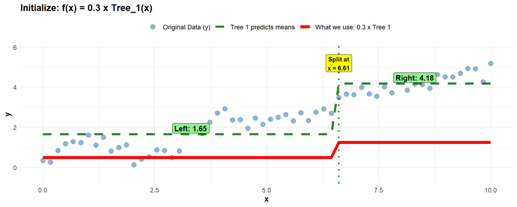

**What’s happening:**

- Tree makes a simple split and predicts the **mean** in each region
- We multiply by \(\lambda = 0.3\) (shrinkage) - only use 30% of the prediction
- This is **“slow learning”** - intentionally conservative to avoid overfitting

## Boosting Step 2: Calculate Residuals (Errors)

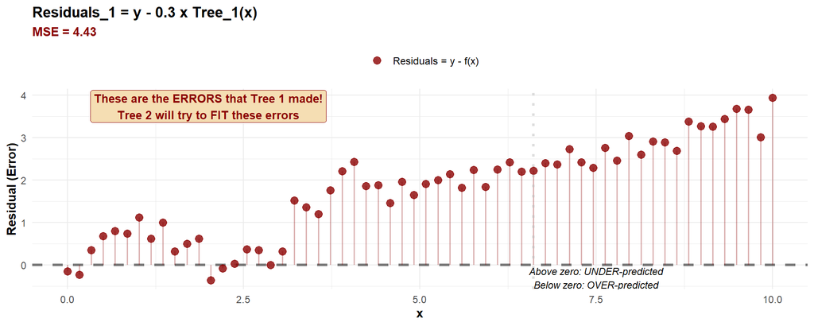

**Key Insight:**

- **Instead of fitting to y again**, Tree 2 will target these residuals
- Residuals = what our current model f(x) is getting wrong
- This is the **core of boosting**: each tree corrects previous mistakes!

## Boosting Step 3: Fit Tree 2 to Residuals

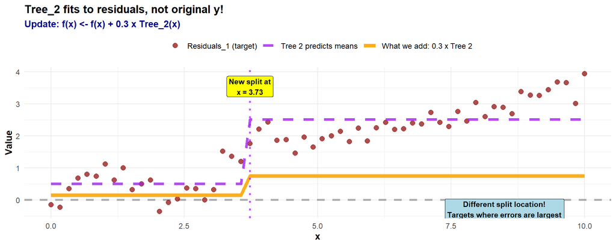

**Key Point:**

- Tree 2 **does NOT fit to y** - it fits to the residuals!
- Split location is **different** from Tree 1 (it targets where errors are large)
- Again multiply by \(\lambda = 0.3\) before adding to our model

## Boosting Step 4: Combined Model Improves!

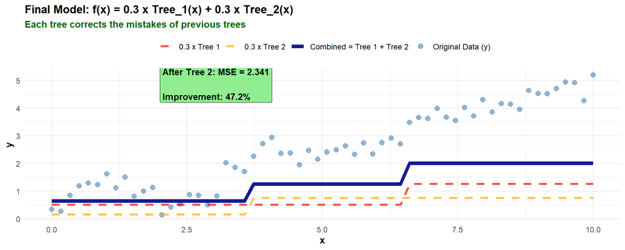

\[f(x) = \lambda \cdot \text{Tree}_1(x) + \lambda \cdot \text{Tree}_2(x) + \lambda \cdot \text{Tree}_3(x) + \ldots\]

- Each tree adds a **correction** to fix remaining errors
- Continue for B iterations (typically 100-5000 trees)
- \(\lambda\) controls how fast we learn (smaller = slower but more robust)

## Why Fit to Residuals? Summary

1. **Tree 1** fits to y → captures main patterns
2. **Tree 2** fits to \(r_1\) → captures what Tree 1 missed
3. **Tree 3** fits to \(r_2\) → captures what Trees 1+2 missed
4. Continue for B iterations…

**Why This Works:**

- Each tree **specializes** in correcting specific errors
- \(\lambda\) (shrinkage) prevents overfitting by taking small steps
- Sequential learning builds complex patterns from simple pieces
- Different splits at each iteration target different problem areas

## Boosting in Practice: Boston Housing

```r
# Load Boston data
set.seed(1)
train_idx <- sample(nrow(Boston), nrow(Boston)/2)
boston_train <- Boston[train_idx, ]
boston_test <- Boston[-train_idx, ]

# Fit boosted regression tree
boost_boston <- gbm(medv ~ ., data = boston_train,
                   distribution = "gaussian",  # For regression
                   n.trees = 5000,           # Number of trees
                   interaction.depth = 4,     # Tree depth
                   shrinkage = 0.01)         # Learning rate

# Make predictions
boost_pred <- predict(boost_boston, boston_test, n.trees = 5000)
boost_mse <- mean((boost_pred - boston_test$medv)^2)
```

```
## Single tree MSE: 35.29 | Random Forest MSE: 18.69 | Boosting MSE: 17.27
```

## Visualizing Boosting Performance Over Iterations

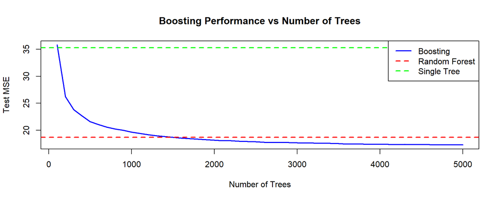

```
## Optimal number of trees: 5000 | Minimum test MSE: 17.27
```

## Variable Importance: Boosting vs Random Forest

**Random Forest Variable Importance:**

- **Mean Decrease in Gini/Impurity**: Total reduction in node impurity from splits on that variable, averaged across all trees
- **Mean Decrease in Accuracy**: How much accuracy drops when the variable is randomly permuted (if `importance=TRUE`)

**Gradient Boosting Variable Importance:**

- **Relative Influence**: Sum of squared improvements in the loss function from splits on that variable across all trees
- Measures how much each variable contributes to reducing the overall prediction error
- Weighted by the number of observations at each split

**Summary**

- Both aim to quantify “how useful is this variable,” but calculate it differently
- In practice, they often (but not always) agree on which variables are most important

## Visualizing Variable Importance in Boosting

- There is a built-in function for plotting boosting importance

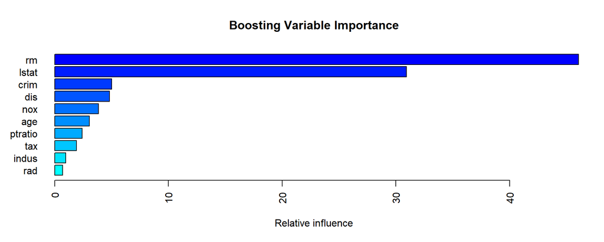

```
##             var     rel.inf
## rm           rm 46.06494256
## lstat     lstat 30.94388040
## crim       crim  5.02227159
## dis         dis  4.82793582
## nox         nox  3.86939862
## age         age  3.04092341
## ptratio ptratio  2.40796224
## tax         tax  1.92555083
## indus     indus  0.98761942
## rad         rad  0.70114514
## zn           zn  0.14913694
## chas       chas  0.05923304
```

```r
# Variable importance from boosting
summary(boost_boston, cBars = 10, main = "Boosting Variable Importance",las = 2)
```

## Tuning Boosting Parameters

**The Tuning Process:**

- **Shrinkage (λ)**: Controls the learning rate - how much each tree contributes
  - Smaller values (0.001-0.01) require more trees but often perform better
  - Larger values (0.1-0.2) learn faster but may overfit
- **Number of Trees (B)**: Total iterations of boosting
  - Too few: underfitting (high bias)
  - Too many: overfitting (high variance)
- **Strategy**: For each shrinkage value, test multiple tree counts to find the optimal combination
- **Trade-off**: Smaller shrinkage needs more trees; larger shrinkage needs fewer trees

```
##   shrinkage      mse optimal_trees
## 1     0.010 16.36055          9100
## 2     0.100 17.35814          2100
## 3     0.200 17.79085          5100
## 4     0.001 19.38708          9100
```

```
##
## Best shrinkage parameter: 0.01
```

## Interaction Depth: Controlling Model Complexity

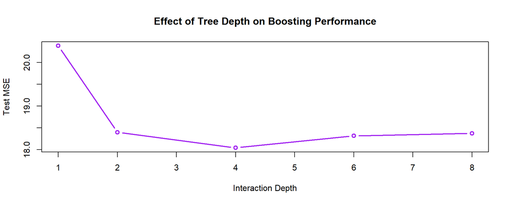

- Too shallow (depth = 1-2): May miss important patterns
- Just right (depth = 3-5): Balances complexity and generalization
- Too deep (depth = 6+): Overfits to training data noise

## Tuning parameters with Cross-Validation

- **No OOB error:** Unlike Random Forest, boosting doesn’t use bootstrap sampling
- **Sequential training:** Each tree uses all training observations
- **Solution:** Must use cross-validation to estimate test error and tune parameters

Use the `cv.folds` option in `gbm` to accomplish this

- `cv.folds` in `gbm` **only tunes the number of trees** (not shrinkage or interaction.depth)
- As boosting builds trees sequentially (1, 2, 3, …, n.trees), it calculates CV error at each iteration
- Helps find the optimal stopping point to prevent overfitting
- Other parameters (shrinkage, interaction.depth) must be tuned manually with multiple model fits

```r
# Fit with 5-fold cross-validation
boost_cv <- gbm(medv ~ ., data = boston_train,
               distribution = "gaussian",
               n.trees = 5000,
               interaction.depth = 4,     # Fixed - not tuned by CV
               shrinkage = 0.01,          # Fixed - not tuned by CV
               cv.folds = 5)              # Enables CV for finding optimal trees
# Find optimal number of trees using CV error
best_iter <- gbm.perf(boost_cv, method = "cv")
# Make predictions using optimal number of trees
pred_cv <- predict(boost_cv, boston_test, n.trees = best_iter)
```

## Results

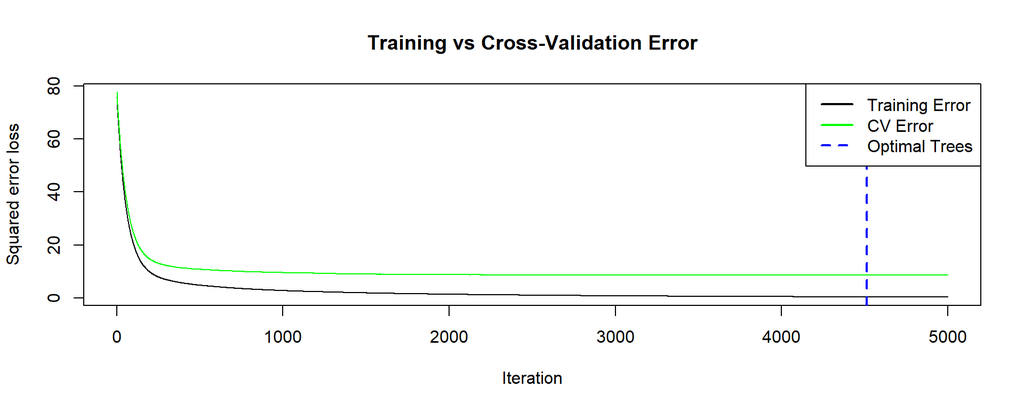

## Partial Dependence Plots for Boosting

- The `gbm` package includes built-in partial dependence plotting with `plot(gbm_object, i.var = "variable_name")`
- Automatically handles the complexity of averaging over other predictors

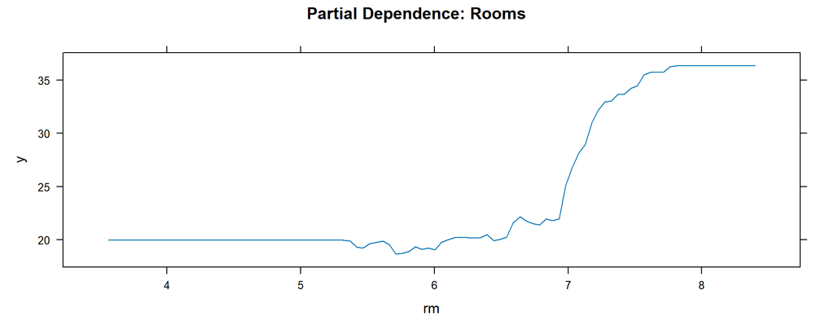

```r
plot(boost_boston, i.var = "rm",  main = "Partial Dependence: Rooms")
```

## Boosting for Classification: Credit Default

| Aspect | **gbm (Boosting)** | **randomForest** |
| --- | --- | --- |
| **Outcome variable** | Requires 0/1 numeric | Accepts factor (Yes/No) |
| **Distribution** | Must specify `distribution = "bernoulli"` | Automatic detection |
| **Predictions** | Returns probabilities (needs `type = "response"`) | Returns classes directly |
| **Class conversion** | Manual threshold (e.g., `> 0.5`) | Not needed |

```r
Default$default_binary <- ifelse(Default$default == "Yes", 1, 0)

train_idx <- sample(nrow(Default), 0.7 * nrow(Default))
default_train <- Default[train_idx, ]
default_test <- Default[-train_idx, ]

boost_default <- gbm(default_binary ~ balance + income + student,
                     data = default_train,
                     distribution = "bernoulli",
                     n.trees = 2000, interaction.depth = 3, shrinkage = 0.01)

boost_prob <- predict(boost_default, default_test,
                     n.trees = 2000, type = "response")

boost_pred_class <- ifelse(boost_prob > 0.5, "Yes", "No")
```

## Types of Boosting Available in R

**Major Boosting Implementations:**

| Package | Algorithm | Best For | Key Features |
| --- | --- | --- | --- |
| **gbm** | Gradient Boosting | General purpose, learning | Easy to use, good documentation, slow |
| **xgboost** | Extreme Gradient Boosting | Large datasets, competitions | Very fast, parallelizable, regularization |
| **lightgbm** | Light GBM | Very large datasets | Extremely fast, low memory, histogram-based |
| **catboost** | Categorical Boosting | Categorical features | Automatic handling of categories, robust |
| **adabag** | AdaBoost | Binary classification | Classic algorithm, educational |
| **mboost** | Model-based Boosting | Statistical modeling | Linear models, GAMs, survival analysis |

- **Learning:** Start with `gbm` (best documentation and examples)
- **Production/Competition:** Use `xgboost` or `lightgbm` (faster, better performance)
- **Categorical data:** Consider `catboost`
- **Research/Statistics:** Use `mboost` for interpretable models

## Comparing All Tree Methods

```
##          Method Test_MSE R_squared       Validation Interp Overfitting Tuning
## 1   Single Tree    35.29      0.61         Test set   High        High    Low
## 2       Bagging    23.28      0.74        OOB error    Low         Low    Low
## 3 Random Forest    18.69      0.80        OOB error    Low    Very Low Medium
## 4      Boosting    17.27      0.81 Cross-validation    Low      Medium   High
```

## Best Practices for Boosting

**Parameter Tuning Guidelines:**

- **Start with:** `shrinkage = 0.01`, `interaction.depth = 4`, `n.trees = 3000`
- **Cross-validation:** Use `cv.folds` in `gbm()` for automatic tuning
- **Monitor:** Training vs validation error to detect overfitting
- **Shrinkage:** Smaller values (0.001-0.01) often work better with more trees

**Common Mistakes:**

- Using too few trees (< 1000)
- Setting shrinkage too high (> 0.1)
- Ignoring interaction depth effects
- Not monitoring for overfitting

**Computational Considerations:**

- Boosting is **sequential** (can’t parallelize easily)
- Random Forest is **parallel** (faster on multi-core systems)
- For large datasets, consider **XGBoost** or **LightGBM**